# Chapter2

of the Textbook ‘Applied Spatial Data Analysis with R’

## R as a calculator

```r
pi * 10^2
```

```
[1] 314.1593
```

R is translating calculation into function

```r
"*"(pi, "^"(10,2))
```

```
[1] 314.1593
```

Calculations with vectors

```r
pi * (1:5)^2
```

```
[1]  3.141593 12.566371 28.274334 50.265482 78.539816
```

## Printing the result of a calculation

```r
x
```

```
[1] 314.1593
```

Or:

```r
print(x)
```

```
[1] 314.1593
```

Or if you want to define the number of digits:

```r
print(x, digits = 12)
```

```
[1] 314.159265359
```

## Classes of objects

Check class and storage mode:

```r
class(x); typeof(x)
```

[output not shown]

–> determines how object is treated by functions

## Example dataset *cars*

```r
class(cars); typeof(cars)
```

```
[1] "data.frame"
```

```
[1] "list"
```

object data.frame has names and summary methods:

```r
names(cars)
```

```
[1] "speed" "dist"
```

```r
summary(cars)
```

```
     speed           dist
 Min.   : 4.0   Min.   :  2.00
 1st Qu.:12.0   1st Qu.: 26.00
 Median :15.0   Median : 36.00
 Mean   :15.4   Mean   : 42.98
 3rd Qu.:19.0   3rd Qu.: 56.00
 Max.   :25.0   Max.   :120.00
```

## Further methods to get an insight on structure of objects

- ls(): list contents of workspace
- str(): structure of object (size, class)

## Dataframes

- containers for data
- rows: observations
- columns: variables of interest
- can include all types of objects

## Formula

response variable ~ determining variable

```r
class(dist~speed)
```

```
[1] "formula"
```

–> formula typically used to fit linear models

```r
lm(dist~speed, data = cars)
```

```
Call:
lm(formula = dist ~ speed, data = cars)

Coefficients:
(Intercept)        speed
    -17.579        3.932
```

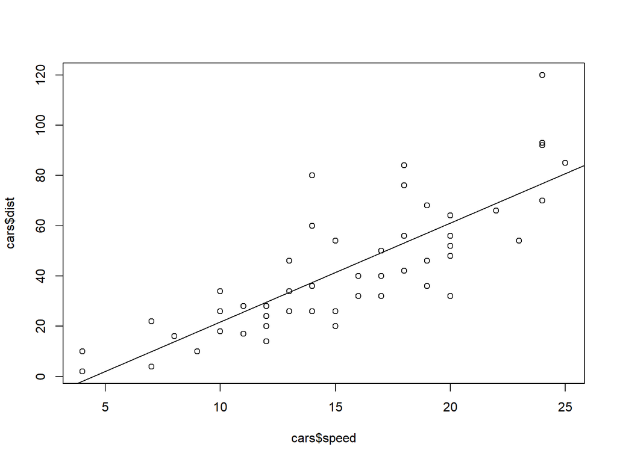

## Creating a factor

```r
cars$qspeed <-  cut(cars$speed, breaks = quantile(cars$speed),
                    include.lowest = TRUE)
```

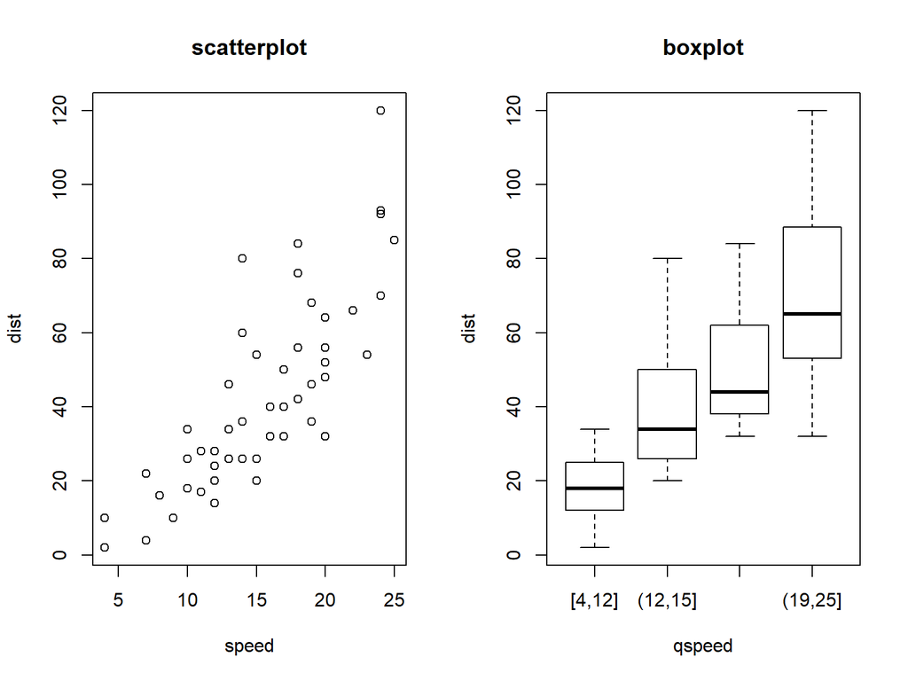

## Spatial Objects

```r
library(sp)
#get complete definition of class (with subclasses)
getClass("Spatial")
```

```
Class "Spatial" [package "sp"]

Slots:

Name:         bbox proj4string
Class:      matrix         CRS

Known Subclasses:
Class "SpatialPoints", directly
Class "SpatialMultiPoints", directly
Class "SpatialGrid", directly
Class "SpatialLines", directly
Class "SpatialPolygons", directly
Class "SpatialPointsDataFrame", by class "SpatialPoints", distance 2
Class "SpatialPixels", by class "SpatialPoints", distance 2
Class "SpatialMultiPointsDataFrame", by class "SpatialMultiPoints", distance 2
Class "SpatialGridDataFrame", by class "SpatialGrid", distance 2
Class "SpatialLinesDataFrame", by class "SpatialLines", distance 2
Class "SpatialPixelsDataFrame", by class "SpatialPoints", distance 3
Class "SpatialPolygonsDataFrame", by class "SpatialPolygons", distance 2
```

## CRS (coordinate reference system) class

```
Class "CRS" [package "sp"]

Slots:

Name:   projargs
Class: character
```

–> character string describing projection

Building a spatial object

```r
#bounding box
m <- matrix(c(0,0,1,1), ncol = 2, dimnames = list(NULL, c("min", "max")))
#missing coordinate system
crs <- CRS(projargs = as.character(NA))
```

```r
S <- Spatial(bbox = m, proj4string = crs)
S
```

```
An object of class "Spatial"
Slot "bbox":
     min max
[1,]   0   1
[2,]   0   1

Slot "proj4string":
CRS arguments: NA
```

R checks coordinate range

```r
bb <-  matrix(c(350,85,370,95), ncol = 2, dimnames = list(NULL, c("min", "max")))
Spatial(bb, proj4string = CRS("+proj=longlat"))
```

```
An object of class "Spatial"
Slot "bbox":
     min max
[1,] 350 370
[2,]  85  95

Slot "proj4string":
CRS arguments: +proj=longlat +ellps=WGS84
```

–> Should show Error: “Geographical CRS given to non-conformat data”

## Spatial Points

defined by a pair of numbers (=coords)

```
Class "SpatialPoints" [package "sp"]

Slots:

Name:       coords        bbox proj4string
Class:      matrix      matrix         CRS

Extends: "Spatial"

Known Subclasses:
Class "SpatialPointsDataFrame", directly
Class "SpatialPixels", directly
Class "SpatialPixelsDataFrame", by class "SpatialPixels", distance 2
```

## Example: spatial points of CRAN mirrors

```r
CRAN_df <-  read.table("CRAN051001a.txt", header = TRUE)
CRAN_mat <- cbind(CRAN_df$long, CRAN_df$lat)
row.names(CRAN_mat) <- 1:nrow(CRAN_mat)
```

Converting matrix into Spatial Points

```r
llCRS <- CRS("+proj=longlat + ellps=WGS84")
CRAN_sp <- SpatialPoints(CRAN_mat, proj4string = llCRS)
```

```r
summary(CRAN_sp)
```

```
Object of class SpatialPoints
Coordinates:
                 min      max
coords.x1 -122.95000 153.0333
coords.x2  -37.81667  57.0500
Is projected: FALSE
proj4string : [+proj=longlat +ellps=WGS84]
Number of points: 54
```

## Methods and functions for SpatialPoints

- bbox(): bounding box of object
  - first row: west-east range
  - second row: south-north range
- proj4string(): projection string
- coordinates(): extracting coordinates

Example: extract CRAN mirrors in Brazil

```r
brazil <- which(CRAN_df$loc == "Brazil"); brazil
```

```
[1] 4 5 6 7 8
```

```r
coordinates(CRAN_sp)[brazil,]
```

```
  coords.x1 coords.x2
4 -49.26667 -25.41667
5 -42.86667 -20.75000
6 -43.20000 -22.90000
7 -47.63333 -22.71667
8 -46.63333 -23.53333
```

### Indexing of Spatial Points

–> works the same as for data.frames/vectors/…

## Data Frames for SpatialPoints Data

```r
getClass("SpatialPointsDataFrame")
```

```
Class "SpatialPointsDataFrame" [package "sp"]

Slots:

Name:         data  coords.nrs      coords        bbox proj4string
Class:  data.frame     numeric      matrix      matrix         CRS

Extends:
Class "SpatialPoints", directly
Class "Spatial", by class "SpatialPoints", distance 2

Known Subclasses:
Class "SpatialPixelsDataFrame", directly, with explicit coerce
```

## Characteristics of SpatialPointsDataFrames

- data: data.frame
- SpatialPoints
  - coords
  - spatial information: bbox, proj4string
- coords.nrs

–> designed to behave as fas as possible like data frames  
–> standard methods for data.frames work as well

```r
head(CRAN_spdf1)
```

```
             coordinates          place   north     east       loc
1  (153.0333, -27.46667)       Brisbane 27d28'S 153d02'E Australia
2  (144.9667, -37.81667)      Melbourne 37d49'S 144d58'E Australia
3   (16.33333, 48.21667)           Wien 48d13'N  16d20'E   Austria
4 (-49.26667, -25.41667)       Curitiba 25d25'S  49d16'W    Brazil
5    (-42.86667, -20.75)         Viçoza 20d45'S  42d52'W    Brazil
6         (-43.2, -22.9) Rio de Janeiro 22d54'S  43d12'W    Brazil
       long       lat
1 153.03333 -27.46667
2 144.96667 -37.81667
3  16.33333  48.21667
4 -49.26667 -25.41667
5 -42.86667 -20.75000
6 -43.20000 -22.90000
```

```r
names(CRAN_spdf1)
```

```
[1] "place" "north" "east"  "loc"   "long"  "lat"
```

```r
str(model.frame(lat ~long, data = CRAN_spdf1), give.attr = FALSE)
```

```
'data.frame':   54 obs. of  2 variables:
 $ lat : num  -27.5 -37.8 48.2 -25.4 -20.8 ...
 $ long: num  153 145 16.3 -49.3 -42.9 ...
```

## Creating a SpatialPointsDataFrame

- associating correct row of data frame with their point coordinates

```r
#SpatialPointsDataFrame needs two indices: spatial object and column
CRAN_spdf1 <- SpatialPointsDataFrame(CRAN_mat, CRAN_df, proj4string = llCRS,
                                     match.ID = TRUE)
CRAN_spdf1[4,]
```

```
             coordinates    place   north    east    loc      long
4 (-49.26667, -25.41667) Curitiba 25d25'S 49d16'W Brazil -49.26667
        lat
4 -25.41667
```

–> requirements:  
- data and matrix of coords have matching row names  
- match.ID = TRUE

same result if data.frame is re-ordered randomly

```r
s <-  sample(nrow(CRAN_df))
CRAN_spdf2 <-  SpatialPointsDataFrame(CRAN_mat, CRAN_df[s,], proj4string = llCRS,
                                      match.ID = TRUE)
all.equal(CRAN_spdf2, CRAN_spdf1)
```

```
[1] TRUE
```

## Alternative ways

- giving SpatialPointsDataFrame function SpatialPoints object as its first argument

```r
CRAN_spdf4 <-  SpatialPointsDataFrame(CRAN_sp, CRAN_df)
all.equal(CRAN_spdf4, CRAN_spdf2)
```

```
[1] TRUE
```

- assign coordinates to a data frame

```r
CRAN_df0 <-  CRAN_df
coordinates(CRAN_df0) <-  CRAN_mat
proj4string(CRAN_df0) <-  llCRS
all.equal(CRAN_df0, CRAN_spdf2)
```

```
[1] TRUE
```

–> modifies original data frame!

## Another dataset: tracking data of a turtle

```r
turtle_df <- read.csv("seamap105_mod.csv")
summary(turtle_df)
```

```
       id              lat             lon
 Min.   :  1.00   Min.   :21.57   Min.   :-179.88
 1st Qu.: 99.25   1st Qu.:24.36   1st Qu.:-147.38
 Median :197.50   Median :25.64   Median :-119.64
 Mean   :197.50   Mean   :27.21   Mean   : -21.52
 3rd Qu.:295.75   3rd Qu.:27.41   3rd Qu.: 153.66
 Max.   :394.00   Max.   :39.84   Max.   : 179.93

                obs_date
 01/02/1997 04:16:53:  1
 01/02/1997 05:56:25:  1
 01/04/1997 17:41:54:  1
 01/05/1997 17:20:07:  1
 01/06/1997 04:31:13:  1
 01/06/1997 06:12:56:  1
 (Other)            :388
```

### Preprocessing of the data: Re-order input data frame by timestamp

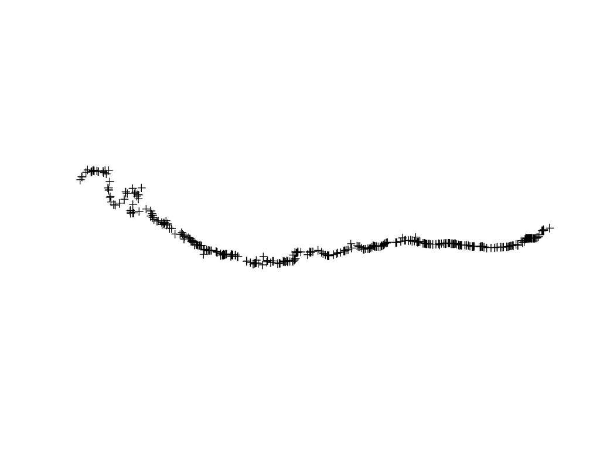

```r
timestamp <- as.POSIXlt(strptime(as.character(turtle_df$obs_date), "%m/%d/%Y %H:%M:%S"),
                        "GMT")
turtle_df1 <- data.frame(turtle_df, timestamp = timestamp)
turtle_df1$lon <- ifelse(turtle_df1$lon < 0, turtle_df1$lon + 360, turtle_df1$lon)
turtle_sp <- turtle_df1[order(turtle_df1$timestamp),]
coordinates(turtle_sp) <- c("lon", "lat")
proj4string(turtle_sp) <- CRS("+proj=longlat +ellps=WGS84")
```

## SpatialLines

```r
getClass("Line")
```

```
Class "Line" [package "sp"]

Slots:

Name:  coords
Class: matrix

Known Subclasses: "Polygon"
```

list of **Line** objects forms **Lines** slot

```r
getClass("Lines")
```

```
Class "Lines" [package "sp"]

Slots:

Name:      Lines        ID
Class:      list character
```

**SpatialLines** object contains spatial information

```r
getClass("SpatialLines")
```

```
Class "SpatialLines" [package "sp"]

Slots:

Name:        lines        bbox proj4string
Class:        list      matrix         CRS

Extends: "Spatial"

Known Subclasses: "SpatialLinesDataFrame"
```

–> summary: Line -> Lines -> SpatialLines

## Example of a Spatial Line Object

```r
library(maps)
japan <-  map("world", "japan", plot = FALSE)
p4s <- CRS("+proj=longlat +ellps=WGS84")
library(maptools)
#conversion to SpatialLines by using map2SpatialLines function in maptools
SLjapan <- map2SpatialLines(japan, proj4string =p4s)
str(SLjapan, max.level = 2)
```

```
Formal class 'SpatialLines' [package "sp"] with 3 slots
  ..@ lines      :List of 34
  ..@ bbox       : num [1:2, 1:2] 123.7 24.3 145.8 45.5
  .. ..- attr(*, "dimnames")=List of 2
  ..@ proj4string:Formal class 'CRS' [package "sp"] with 1 slot
```

## Characteristics of SpatialLines

- lines
  - Line: coords
  - ID
- spatial information: bbox, proj4string

## Converting SpatialLines into SpatialLinesDataFrame

–> ContourLines2SLDF function of maptools package

```r
volcano_sl <- ContourLines2SLDF(contourLines(volcano))
t(slot(volcano_sl, "data"))
```

```
      C_1   C_2   C_3   C_4   C_5   C_6   C_7   C_8   C_9   C_10
level "100" "110" "120" "130" "140" "150" "160" "170" "180" "190"
```

–> ten separate contour level labels

## Another example: shoreline data (Mapgen format) into SpatialLines

```r
llCRS <- CRS("+proj=longlat +ellps=WGS84")
auckshore <-  MapGen2SL("auckland_mapgen.dat", llCRS)
summary(auckshore)
```

```
Object of class SpatialLines
Coordinates:
    min   max
x 174.2 175.3
y -37.5 -36.5
Is projected: FALSE
proj4string : [+proj=longlat +ellps=WGS84]
```

*auckshore* still only SpatialLines

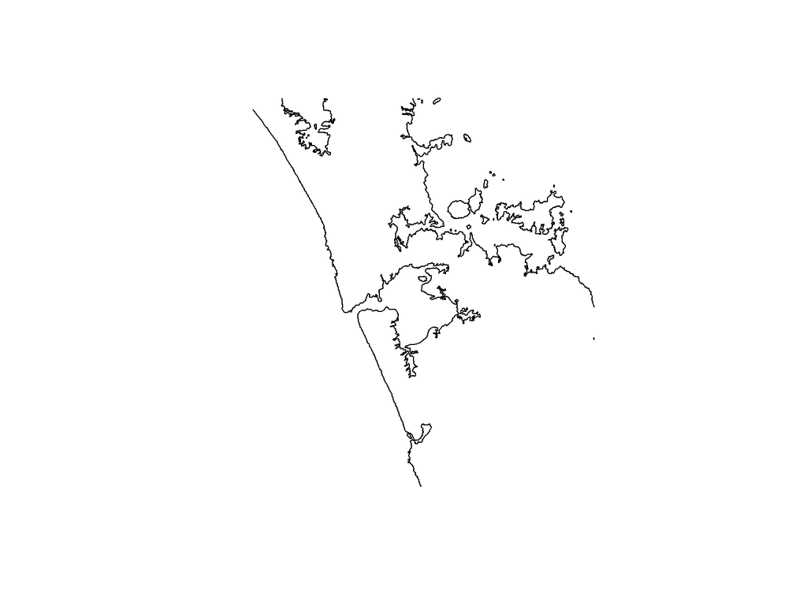

–> polygons formed by line rings cannot be filled

## SpatialPolygons

```r
lns <- slot(auckshore, "lines")
#length of the Lines slot of each Lines object in the lines list
table(sapply(lns, function(x) length(slot(x,"Lines"))))
```

```
 1
80
```

–> checking equality of the first and last coordinates of the first Line object in each Lines object

```r
islands_auck <-  sapply(lns, function(x){
  crds <- slot(slot(x,"Lines")[[1]], "coords")
  identical(crds[1,], crds[nrow(crds),])
})
table(islands_auck)
```

```
islands_auck
FALSE  TRUE
   16    64
```

## Class: Polygon

```r
getClass("Polygon")
```

```
Class "Polygon" [package "sp"]

Slots:

Name:    labpt    area    hole ringDir  coords
Class: numeric numeric logical integer  matrix

Extends: "Line"
```

- label point: centroid of the polygon
- area
- hole
- ring direction

## Polygons

```r
getClass("Polygons")
```

```
Class "Polygons" [package "sp"]

Slots:

Name:   Polygons plotOrder     labpt        ID      area
Class:      list   integer   numeric character   numeric
```

- list of polygon objects
- identifying string
- label point: label point of the polygon with the largest area
- area: sum of all polygons

## SpatialPolygons

```r
getClass("SpatialPolygons")
```

```
Class "SpatialPolygons" [package "sp"]

Slots:

Name:     polygons   plotOrder        bbox proj4string
Class:        list     integer      matrix         CRS

Extends: "Spatial"

Known Subclasses:
Class "SpatialPolygonsDataFrame", directly, with explicit coerce
```

- set of Polygons objects
- spatial information: bbox, project information

## Creating a SpatialPolygons object

```r
#Chosing only lines in Auckland shoreline data set which are closed polygons
islands_sl <- auckshore[islands_auck]
list_of_Lines <- slot(islands_sl, "lines")
islands_sp <- SpatialPolygons(lapply(list_of_Lines, function(x){Polygons(list(Polygon
  (slot(slot(x,"Lines")[[1]], "coords"))), ID = slot(x, "ID"))}), proj4string
  =CRS("+proj=longlat +ellps=WGS84"))
summary(islands_sp)
```

```
Object of class SpatialPolygons
Coordinates:
        min       max
x 174.30297 175.22791
y -37.43877 -36.50033
Is projected: FALSE
proj4string : [+proj=longlat +ellps=WGS84]
```

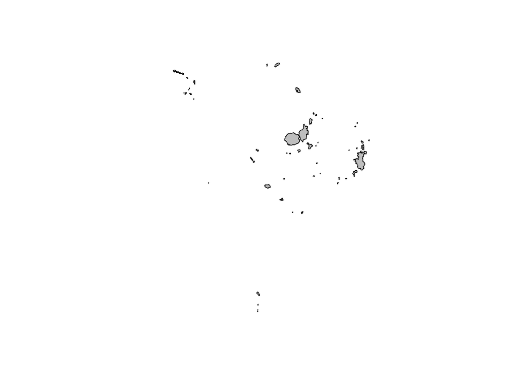

## SpatialPolgyongsDataFrame

–> bring together spatial representations of polygons with data (ID of polygons ~ row number of data.frame)

### Example data: Scholastic Aptitude Test

```r
#state boundary polygons provided in maps package
state.map <- map("state", plot = FALSE, fill = TRUE)
IDs <- sapply(strsplit(state.map$names, ":"), function(x) x[1])
state.sp <- map2SpatialPolygons(state.map, IDs = IDs, proj4string =
  CRS("+proj=longlat + ellps=WGS84"))
```

```r
#subset to the matched rows of the data frame
sat <- read.table("state.sat.data_mod.txt", row.names = 5, header = TRUE)
str(sat)
```

```
'data.frame':   52 obs. of  4 variables:
 $ oname : Factor w/ 52 levels "ala","alaska",..: 1 2 3 4 5 6 7 9 8 10 ...
 $ vscore: int  561 516 524 563 497 536 510 503 494 499 ...
 $ mscore: int  555 514 525 556 514 540 509 497 478 498 ...
 $ pc    : int  9 50 34 6 49 32 80 67 77 53 ...
```

```r
id <- match(row.names(sat), row.names(state.sp))
row.names(sat)[is.na(id)]
```

```
[1] "alaska" "hawaii" "usa"
```

Caution: R is case-sensitive! “Alaska” != “alaska”

```r
sat1 <- sat[!is.na(id),]
state.spdf <- SpatialPolygonsDataFrame(state.sp,sat1)
str(state.spdf, max.level = 2)
```

```
Formal class 'SpatialPolygonsDataFrame' [package "sp"] with 5 slots
  ..@ data       :'data.frame': 49 obs. of  4 variables:
  ..@ polygons   :List of 49
  ..@ plotOrder  : int [1:49] 42 25 4 30 27 2 5 49 36 22 ...
  ..@ bbox       : num [1:2, 1:2] -124.7 25.1 -67 49.4
  .. ..- attr(*, "dimnames")=List of 2
  ..@ proj4string:Formal class 'CRS' [package "sp"] with 1 slot
```

## Drop some polygons

```r
#drop District of Columbia
DC <- "district of columbia"
not_dc <- !(row.names(state.spdf) == DC)
state.spdf1 <-  state.spdf[not_dc,]
dim(state.spdf); dim(state.spdf1)
```

```
[1] 49  4
```

```
[1] 48  4
```

```r
summary(state.spdf1)
```

```
Object of class SpatialPolygonsDataFrame
Coordinates:
         min       max
x -124.68134 -67.00742
y   25.12993  49.38323
Is projected: FALSE
proj4string : [+proj=longlat +ellps=WGS84]
Data attributes:
     oname        vscore          mscore            pc
 ala    : 1   Min.   :479.0   Min.   :475.0   Min.   : 4.00
 ariz   : 1   1st Qu.:506.2   1st Qu.:505.2   1st Qu.: 9.00
 ark    : 1   Median :530.5   Median :532.0   Median :28.50
 calif  : 1   Mean   :534.6   Mean   :534.9   Mean   :35.58
 colo   : 1   3rd Qu.:563.0   3rd Qu.:558.5   3rd Qu.:63.50
 conn   : 1   Max.   :594.0   Max.   :605.0   Max.   :80.00
 (Other):42
```

## Holes and Rings

- GIS: boundaries between polygons only stored once –> topological representation of polygons
- R: non-topological representation of polygons –> solution:
  - logical flag *hole*
  - ring direction
    - clockwise rings: no holes
    - anti-clockwise rings: holes

## Example data: Canadian shore of Lake Huron

```r
load("high.RData")
manitoulin_sp <- high[[4]]
length(slot(manitoulin_sp, "polygons"))
```

```
[1] 1
```

```r
sapply(slot(slot(manitoulin_sp, "polygons")[[1]], "Polygons"), function(x) slot
  (x, "hole"))
```

```
 [1] FALSE  TRUE FALSE  TRUE  TRUE FALSE  TRUE FALSE FALSE FALSE FALSE
[12] FALSE FALSE FALSE FALSE FALSE FALSE FALSE FALSE
```

```r
sapply(slot(slot(manitoulin_sp, "polygons")[[1]], "Polygons"), function(x) slot
  (x, "ringDir"))
```

```
 [1]  1 -1  1 -1 -1  1 -1  1  1  1  1  1  1  1  1  1  1  1  1
```

## rgeos packages

–> each hole must be associated with its exterior ring

```r
library(rgeos)
manitoulin_sp <- createSPComment(manitoulin_sp)
sapply(slot(manitoulin_sp, "polygons"), comment)
```

```
[1] "0 1 0 3 3 0 3 0 0 0 0 0 0 0 0 0 0 0 0"
```

## SpatialGrid and SpatialPixel Objects

```r
getClass("GridTopology")
```

```
Class "GridTopology" [package "sp"]

Slots:

Name:  cellcentre.offset          cellsize         cells.dim
Class:           numeric           numeric           integer
```

## Converting vector data into GridTopology

```r
bb <- bbox(manitoulin_sp)
bb
```

```
     min   max
r1 277.0 278.0
r2  45.7  46.2
```

```r
cs <-  c(0.01, 0.01) #defining cell size [°]
cc <-  bb[,1] + (cs/2)
cd <-  ceiling(diff(t(bb))/cs)
manitoulin_grd <-  GridTopology(cellcentre.offset = cc, cellsize = cs, cells.dim = cd)
manitoulin_grd
```

```
                       r1     r2
cellcentre.offset 277.005 45.705
cellsize            0.010  0.010
cells.dim         100.000 50.000
```

## SpatialGrids

–> GridTopology + spatial information

```r
getClass("SpatialGrid")
```

```
Class "SpatialGrid" [package "sp"]

Slots:

Name:          grid         bbox  proj4string
Class: GridTopology       matrix          CRS

Extends: "Spatial"

Known Subclasses: "SpatialGridDataFrame"
```

```r
p4s <- CRS(proj4string(manitoulin_sp))
manitoulin_SG <-SpatialGrid(manitoulin_grd, proj4string = p4s)
summary(manitoulin_SG)
```

```
Object of class SpatialGrid
Coordinates:
     min   max
r1 277.0 278.0
r2  45.7  46.2
Is projected: FALSE
proj4string :
[+proj=longlat +datum=WGS84 +ellps=WGS84 +towgs84=0,0,0]
Grid attributes:
   cellcentre.offset cellsize cells.dim
r1           277.005     0.01       100
r2            45.705     0.01        50
```

```r
library(raster)
raster1 <-  raster("Auckland SRTM/70042108.tif")
auck_el1 <- as(raster1,"SpatialGridDataFrame")
class(auck_el1)
```

```
[1] "SpatialGridDataFrame"
attr(,"package")
[1] "sp"
```

```r
#GridTopology object
slot(auck_el1, "grid")
```

```
                            s1            s2
cellcentre.offset 1.742004e+02 -3.749958e+01
cellsize          8.333333e-04  8.333333e-04
cells.dim         1.320000e+03  1.200000e+03
```

```r
#extent of the SpatialGrid
slot(auck_el1, "bbox")
```

```
     min   max
s1 174.2 175.3
s2 -37.5 -36.5
```

```r
#total size of SpatialGridDataFrame
object.size(auck_el1)
```

```
25348408 bytes
```

```r
object.size(slot(auck_el1, "data"))
```

```
25344784 bytes
```

```r
#almost half of the data at or below sea level --> set to NA
is.na(auck_el1$BinValues) <- auck_el1$BinValues <= 0
summary(auck_el1$BinValues)
```

[output not shown]

–> results in high percentage of missing data

## Another class for spatial grids: SpatialPixels

```r
auck_el2 <- as(auck_el1, "SpatialPixelsDataFrame")
object.size(auck_el2)
```

```
63349816 bytes
```

## Taking only raster cells over 500m

```r
auck_el_500_1 <- auck_el2[!is.na(auck_el2$BinValues),]
auck_el_500 <- auck_el_500_1[auck_el_500_1$BinValues > 500,]
```

```r
summary(auck_el_500@data)
```

```
     COUNT         BinValues
 Min.   : 1.00   Min.   :501.0
 1st Qu.: 6.00   1st Qu.:520.0
 Median : 9.00   Median :544.0
 Mean   : 9.02   Mean   :549.6
 3rd Qu.:11.00   3rd Qu.:574.0
 Max.   :19.00   Max.   :661.0
```

```r
object.size(auck_el_500)
```

```
34904 bytes
```

## Creating SpatialPixels directly from SpatialPoints

```r
data("meuse.grid") #provided with sp
mg_SP <- SpatialPoints(cbind(meuse.grid$x, meuse.grid$y))
summary(mg_SP)
```

```
Object of class SpatialPoints
Coordinates:
             min    max
coords.x1 178460 181540
coords.x2 329620 333740
Is projected: NA
proj4string : [NA]
Number of points: 3103
```

```r
mg_SPix0 <-  SpatialPixels(mg_SP)
summary(mg_SPix0)
```

```
Object of class SpatialPixels
Coordinates:
             min    max
coords.x1 178440 181560
coords.x2 329600 333760
Is projected: NA
proj4string : [NA]
Number of points: 3103
Grid attributes:
          cellcentre.offset cellsize cells.dim
coords.x1            178460       40        78
coords.x2            329620       40       104
```

```r
prod(slot(slot(mg_SPix0, "grid"), "cells.dim"))
```

```
[1] 8112
```

–> over half of the grid is not present in SpatialPixels representation (outside of study area)

## Alternatively: Coerce SpatialPoints object to SpatialPixel object

```r
mg_SPix1 <- as(mg_SP, "SpatialPixels")
summary(mg_SPix1)
```

```
Object of class SpatialPixels
Coordinates:
             min    max
coords.x1 178440 181560
coords.x2 329600 333760
Is projected: NA
proj4string : [NA]
Number of points: 3103
Grid attributes:
          cellcentre.offset cellsize cells.dim
coords.x1            178460       40        78
coords.x2            329620       40       104
```

## raster package

uses sp classes for vector data and adds new classes and methods for raster data

```r
library(raster)
r <-  raster("Auckland SRTM/70042108.tif")
class(r)
```

```
[1] "RasterLayer"
attr(,"package")
[1] "raster"
```

```r
# raster objects can be held on disk rather than in memory
inMemory(r)
```

```
[1] FALSE
```

## Some statistics on raster layers

```r
cellStats(r,max);cellStats(r, min)
```

```
[1] 686
```

```
[1] -34
```

## Remove values of less than or equal to zero

–> in blocks of rows, storing the data ot the new object in a temporary file

```r
out <-raster(r)
bs <- blockSize(out)
out <- writeStart(out, filename = tempfile(), overwrite = TRUE)
for (i in 1:bs$n) {
  v <- getValues(r, row = bs$row[i], nrows = bs$nrows[i])
  v[v<=0] <- NA
  writeValues(out, v, bs$row[i])
}
out <- writeStop(out)
cellStats(out, min); cellStats(out, max)
```

```
[1] 1
```

```
[1] 686
```

## Plot methods of raster

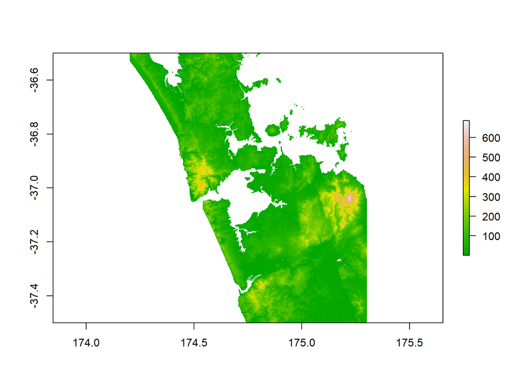

## Coercion between classes in sp and raster

```r
r1 <- as(out, "SpatialGridDataFrame")
r2 <-  as(r1,"RasterLayer")
```

```r
summary(r1)
```

```
Object of class SpatialGridDataFrame
Coordinates:
     min   max
s1 174.2 175.3
s2 -37.5 -36.5
Is projected: FALSE
proj4string :
[+proj=longlat +datum=WGS84 +no_defs +ellps=WGS84 +towgs84=0,0,0]
Grid attributes:
   cellcentre.offset     cellsize cells.dim
s1         174.20042 0.0008333333      1320
s2         -37.49958 0.0008333333      1200
Data attributes:
     layer
 Min.   :  1.0
 1st Qu.: 23.0
 Median : 53.0
 Mean   : 78.1
 3rd Qu.:106.0
 Max.   :686.0
 NA's   :791938
```

```r
summary(r2)
```

```
         layer
Min.         1
1st Qu.     23
Median      53
3rd Qu.    106
Max.       686
NA's    791938
```